# Replication Assignment

Abby Robinson

12/10/2021

# Replicating Results from “Complex dynamics underlie the evolution of imperfect wing pattern convergence in butterflies”

In this module, I will walk through replicating the summary statistics, Generalize Linear Model and Survival analyses and recreating Figure 1 in Finkbeiner et al. 2017.

# Packages

> You will need to install several packages for each analysis

**To load the data from github, install,** [{curl}](https://www.rdocumentation.org/packages/curl/versions/4.3.2/topics/curl)

**For the Generalized Linear Model Analysis, install,** [{broom}](https://www.rdocumentation.org/packages/phytools/versions/0.7-90), [{lmtest}](https://cran.r-project.org/web/packages/lmtest/lmtest.pdf)

**For the Survival Analysis, install,** [{survival}](https://cran.r-project.org/web/packages/survival/survival.pdf), [{survminer}](https://cran.r-project.org/web/packages/survminer/readme/README.html)

**For Reproducing Figures** [{ggplot2}](https://www.rdocumentation.org/packages/ggplot2/versions/3.3.5), [{ggimage}](https://www.rdocumentation.org/packages/ggmap/versions/3.0.0/topics/ggimage), [{dplyr}](https://www.rdocumentation.org/packages/dplyr/versions/0.7.8)

# Introduction

The genus *Adelpha* is a large and diverse butterfly lineage that inhabits the Neotropics and exhibits widespread convergent evolution in wing patterns. In this paper, [Finkbeiner et al. 2017](https://onlinelibrary.wiley.com/doi/full/10.1111/evo.13165) conducts field predation experiments in Costa Rica using artificial butterfly facsimiles to assess whether this widespread convergence is a product of selection for mimicry.

They hypothesize that the putative palatable mimic species *Adelpha serpa* would benefit (in the form of low predation rates) by resembling the putative, chemically-defended model species, *Adelpha iphiclus*

# Dowload the Data

To replicate the analyses from this paper, we will need to download two different datasets; one is count data, which will allow us to run a generalized linear model with Poisson distribution, and the other is binomial data, which will allow is to run the survival analyses.

Let’s start by loading the {curl} package

```r
library(curl)
```

Now lets load the **Count Data** into our markdown file using the {curl} command

```r
c <- curl("https://raw.githubusercontent.com/butterfliesrcool/BI588_Replication_Assignment/main/Adelpha2016.csv")
count.data  <- read.csv(c, header = TRUE, sep = ",", stringsAsFactors = FALSE)
head(count.data) #we can use the head function to view the first 10 rows in the dataset
```

```
##   day site species attacks
## 1   1    1 evarete       0
## 2   1    2 evarete       0
## 3   1    3 evarete       1
## 4   1    4 evarete       0
## 5   1    5 evarete       0
## 6   1    6 evarete       0
```

Great! Now we can load the **Binomial Data** as well using the same method

```r
b <- curl("https://raw.githubusercontent.com/butterfliesrcool/BI588_Replication_Assignment/main/Adelpha2016_binomial.csv")
binomial.data  <- read.csv(b, header = TRUE, sep = ",", stringsAsFactors = FALSE)
head(binomial.data)
```

```
##   day site species attacks
## 1   1    1 evarete       0
## 2   1    2 evarete       0
## 3   1    3 evarete       1
## 4   1    4 evarete       0
## 5   1    5 evarete       0
## 6   1    6 evarete       0
```

At first glance these data sets look the same, but the binomial data set is substantially longer because it accounts for all facsimiles present at each study site. This can change the degrees of freedom, which can affect the significance of our analyses.

```r
length(count.data$attacks)
```

```
## [1] 1600
```

```r
length(binomial.data$attacks)
```

```
## [1] 8000
```

# Summary Statistics

In her 2017 publication, Susan Finkbeiner reports, “Our primary predation experiment tested whether Adelpha species with locally convergent wing patterns experience reduced predation rates compared to novel and known palatable butterfly prey. Two-thousand total artificial butterfly facsimiles were used in this study, which yielded 189 combined avian attacks: 52 on Junonia (10.4% attacked), 30 on A. iphiclus (6.0% attacked), 56 on A. serpa (11.2% attacked), and 51 on A. leucopthalma (10.2% at- tacked, Fig. 1A).”

I will replicated these summary statistics below.

We can use the subset function to subset only the data that represent attacks on butterfly facsimiles. This can be useful when working with large data sets like this that contains a lot of zeros. We can also use the aggregate function to look at the total attacks on each species

```r
attacks <- subset(count.data, attacks >= "1", drop = FALSE)
sum(attacks$attacks) #total attacks = 189
```

```
## [1] 189
```

```r
species <- aggregate(x= attacks$attacks, by= list(attacks$species), FUN=sum)
species #summarized attacks on all four species across the 4-day experiment
```

```
##        Group.1  x
## 1      evarete 52
## 2     iphiclus 30
## 3 leucopthalma 51
## 4        serpa 56
```

We can also calculate the attack rates on each species by dividing the total number of attacks by the total number of facsimiles, which is 500 for each species.

To calculate the over all attack rate, we can first confirm that both our count and binomial data yield the same attack total

```r
sum(count.data$attacks)
```

```
## [1] 189
```

```r
sum(binomial.data$attacks)
```

```
## [1] 189
```

Then we can divide this total by the total number of facsimiles used in the experiment to get the overall attack rate

```r
total.facsimilies <- 2000
oat <- (sum(binomial.data$attacks))/total.facsimilies
oat
```

```
## [1] 0.0945
```

```r
#Overall attack rate on facsimilies is 9.45%
```

We can also calculate the attack rate by species using the cbind function

```r
name <- c("evarete", "iphiclus", "leucopthalma", "serpa")
total.attacks <- c(52, 30, 51, 56)
rates <- cbind((total.attacks/500)*100)
rates
```

```
##      [,1]
## [1,] 10.4
## [2,]  6.0
## [3,] 10.2
## [4,] 11.2
```

```r
rate.data <- data.frame(name, total.attacks, rates)
rate.data
```

```
##           name total.attacks rates
## 1      evarete            52  10.4
## 2     iphiclus            30   6.0
## 3 leucopthalma            51  10.2
## 4        serpa            56  11.2
```

Another way to calculate the attack rates for each species:

```r
no.zero <- subset(binomial.data, attacks >= "1", drop = FALSE)
a <- table(no.zero$attacks, no.zero$species)
rates <- (a/500)*100
rates
```

```
##
##     evarete iphiclus leucopthalma serpa
##   1    10.4      6.0         10.2  11.2
```

We can also use the subset and aggregate functions to list the attack totals for each species by day

```r
eva <- subset(count.data, species == "evarete", drop = FALSE)
aggregate(x= eva$attacks, by= list(eva$day), FUN=sum)
```

```
##   Group.1  x
## 1       1 18
## 2       2 12
## 3       3 12
## 4       4 10
```

```r
iph <- subset(count.data, species == "iphiclus", drop = FALSE)
aggregate(x= iph$attacks, by= list(iph$day), FUN=sum)
```

```
##   Group.1  x
## 1       1 17
## 2       2  6
## 3       3  5
## 4       4  2
```

```r
leu <- subset(count.data, species == "leucopthalma", drop = FALSE)
aggregate(x= leu$attacks, by= list(leu$day), FUN=sum)
```

```
##   Group.1  x
## 1       1 20
## 2       2 10
## 3       3  9
## 4       4 12
```

```r
ser <- subset(count.data, species == "serpa", drop = FALSE)
aggregate(x= ser$attacks, by= list(ser$day), FUN=sum)
```

```
##   Group.1  x
## 1       1 25
## 2       2 15
## 3       3 11
## 4       4  5
```

# Generalized Linear Model

Load the required packages

```r
library(broom)
library(lmtest)
```

In this paper, Finkbeiner reported that she ran a general linear model with Poisson distribution and calculated the 95% confidence intervals, which is represented in the error bars in Figure 1A. She reports a p-value from this analysis of <0.03*, which is consistent with the replicated analysis below.

The most challenging part of recreating this analysis was figuring out how to format the data. I ended up deleting the “day” variable and writing the data as if all attack were reported on the same day. This allowed me to match her reported d.f. values.

First, lets load the new data!

```r
f <- curl("https://raw.githubusercontent.com/butterfliesrcool/BI588_Replication_Assignment/main/adelpha2016totals.csv")
total.data  <- read.csv(f, header = TRUE, sep = ",", stringsAsFactors = FALSE)
head(count.data) #we can use the head function to view the first 10 rows in the dataset
```

```
##   day site species attacks
## 1   1    1 evarete       0
## 2   1    2 evarete       0
## 3   1    3 evarete       1
## 4   1    4 evarete       0
## 5   1    5 evarete       0
## 6   1    6 evarete       0
```

overall glm with all comparisons and 95% confidence intervals as reported in the legend of Figure 1A.

```r
glm <- glm(data = total.data, attacks ~ species, family = "poisson")
summary(glm)
```

```
##
## Call:
## glm(formula = attacks ~ species, family = "poisson", data = total.data)
##
## Deviance Residuals:
##     Min       1Q   Median       3Q      Max
## -1.0583  -1.0198  -0.7746   0.5898   2.3773
##
## Coefficients:
##                     Estimate Std. Error z value Pr(>|z|)
## (Intercept)         -0.65393    0.13868  -4.716 2.41e-06 ***
## speciesiphiclus     -0.55005    0.22927  -2.399   0.0164 *
## speciesleucopthalma -0.01942    0.19708  -0.099   0.9215
## speciesserpa         0.07411    0.19258   0.385   0.7004
## ---
## Signif. codes:  0 '***' 0.001 '**' 0.01 '*' 0.05 '.' 0.1 ' ' 1
##
## (Dispersion parameter for poisson family taken to be 1)
##
##     Null deviance: 433.17  on 399  degrees of freedom
## Residual deviance: 423.64  on 396  degrees of freedom
## AIC: 737.06
##
## Number of Fisher Scoring iterations: 6
```

```r
confint(glm)
```

```
##                          2.5 %     97.5 %
## (Intercept)         -0.9386163 -0.3939055
## speciesiphiclus     -1.0104353 -0.1078296
## speciesleucopthalma -0.4071284  0.3678069
## speciesserpa        -0.3035894  0.4535734
```

She then reported what seemed to be pairwise glms, but I couldn’t find a post hoc test or anything that would give me pairwise comparisons in a glm so I subsetted each species comparison using the subset function and ran additional glms for each, which allowed me to recreate her results.

GLMs that yield significant results:

1. evarete-iphiclus comparison

```r
ei <- subset(total.data, species %in% c("evarete", "iphiclus"), drop = FALSE)
glm1 <- glm(data = ei, attacks ~ species, family = "poisson")
summary(glm1)
```

```
##
## Call:
## glm(formula = attacks ~ species, family = "poisson", data = ei)
##
## Deviance Residuals:
##     Min       1Q   Median       3Q      Max
## -1.0198  -1.0198  -0.7746   0.5898   2.3569
##
## Coefficients:
##                 Estimate Std. Error z value Pr(>|z|)
## (Intercept)      -0.6539     0.1387  -4.716 2.41e-06 ***
## speciesiphiclus  -0.5500     0.2293  -2.399   0.0164 *
## ---
## Signif. codes:  0 '***' 0.001 '**' 0.01 '*' 0.05 '.' 0.1 ' ' 1
##
## (Dispersion parameter for poisson family taken to be 1)
##
##     Null deviance: 202.72  on 199  degrees of freedom
## Residual deviance: 196.74  on 198  degrees of freedom
## AIC: 336.78
##
## Number of Fisher Scoring iterations: 6
```

2. serpa-iphiclus comparison

```r
si <- subset(total.data, species %in% c("serpa", "iphiclus"), drop = FALSE)
glm2 <- glm(data = si, attacks ~ species, family = "poisson")
summary(glm2)
```

```
##
## Call:
## glm(formula = attacks ~ species, family = "poisson", data = si)
##
## Deviance Residuals:
##     Min       1Q   Median       3Q      Max
## -1.0583  -1.0583  -0.7746   0.5288   2.2783
##
## Coefficients:
##              Estimate Std. Error z value Pr(>|z|)
## (Intercept)   -1.2040     0.1826  -6.594 4.27e-11 ***
## speciesserpa   0.6242     0.2263   2.759   0.0058 **
## ---
## Signif. codes:  0 '***' 0.001 '**' 0.01 '*' 0.05 '.' 0.1 ' ' 1
##
## (Dispersion parameter for poisson family taken to be 1)
##
##     Null deviance: 218.66  on 199  degrees of freedom
## Residual deviance: 210.68  on 198  degrees of freedom
## AIC: 351.08
##
## Number of Fisher Scoring iterations: 6
```

3. leucopthalma-iphiclus comparison

```r
li <- subset(total.data, species %in% c("leucopthalma", "iphiclus"), drop = FALSE)
glm3 <- glm(data = li, attacks ~ species, family = "poisson")
summary(glm3)
```

```
##
## Call:
## glm(formula = attacks ~ species, family = "poisson", data = li)
##
## Deviance Residuals:
##     Min       1Q   Median       3Q      Max
## -1.0099  -1.0099  -0.7746   0.6056   2.3773
##
## Coefficients:
##                     Estimate Std. Error z value Pr(>|z|)
## (Intercept)          -1.2040     0.1826  -6.594 4.27e-11 ***
## speciesleucopthalma   0.5306     0.2301   2.306   0.0211 *
## ---
## Signif. codes:  0 '***' 0.001 '**' 0.01 '*' 0.05 '.' 0.1 ' ' 1
##
## (Dispersion parameter for poisson family taken to be 1)
##
##     Null deviance: 205.02  on 199  degrees of freedom
## Residual deviance: 199.51  on 198  degrees of freedom
## AIC: 337.08
##
## Number of Fisher Scoring iterations: 6
```

GLMs that do not yield significant results:

1. leucopthalma-evarete comparison

```r
le <- subset(total.data, species %in% c("leucopthalma", "evarete"), drop = FALSE)
glm4 <- glm(data = le, attacks ~ species, family = "poisson")
summary(glm4)
```

```
##
## Call:
## glm(formula = attacks ~ species, family = "poisson", data = le)
##
## Deviance Residuals:
##     Min       1Q   Median       3Q      Max
## -1.0198  -1.0198  -1.0099   0.5937   2.3773
##
## Coefficients:
##                     Estimate Std. Error z value Pr(>|z|)
## (Intercept)         -0.65393    0.13867  -4.716 2.41e-06 ***
## speciesleucopthalma -0.01942    0.19706  -0.099    0.922
## ---
## Signif. codes:  0 '***' 0.001 '**' 0.01 '*' 0.05 '.' 0.1 ' ' 1
##
## (Dispersion parameter for poisson family taken to be 1)
##
##     Null deviance: 212.97  on 199  degrees of freedom
## Residual deviance: 212.96  on 198  degrees of freedom
## AIC: 385.98
##
## Number of Fisher Scoring iterations: 5
```

2. leucopthalma-serpa comparison

```r
ls <- subset(total.data, species %in% c("leucopthalma", "serpa"), drop = FALSE)
glm5 <- glm(data = ls, attacks ~ species, family = "poisson")
summary(glm5)
```

```
##
## Call:
## glm(formula = attacks ~ species, family = "poisson", data = ls)
##
## Deviance Residuals:
##     Min       1Q   Median       3Q      Max
## -1.0583  -1.0583  -1.0099   0.6056   2.3773
##
## Coefficients:
##              Estimate Std. Error z value Pr(>|z|)
## (Intercept)  -0.67334    0.14002  -4.809 1.52e-06 ***
## speciesserpa  0.09353    0.19354   0.483    0.629
## ---
## Signif. codes:  0 '***' 0.001 '**' 0.01 '*' 0.05 '.' 0.1 ' ' 1
##
## (Dispersion parameter for poisson family taken to be 1)
##
##     Null deviance: 227.13  on 199  degrees of freedom
## Residual deviance: 226.90  on 198  degrees of freedom
## AIC: 400.27
##
## Number of Fisher Scoring iterations: 5
```

3. evarete-serpa comparison

```r
es <- subset(total.data, species %in% c("evarete", "serpa"), drop = FALSE)
glm6 <- glm(data = es, attacks ~ species, family = "poisson")
summary(glm6)
```

```
##
## Call:
## glm(formula = attacks ~ species, family = "poisson", data = es)
##
## Deviance Residuals:
##     Min       1Q   Median       3Q      Max
## -1.0583  -1.0583  -1.0198   0.5898   2.3569
##
## Coefficients:
##              Estimate Std. Error z value Pr(>|z|)
## (Intercept)  -0.65393    0.13867  -4.716 2.41e-06 ***
## speciesserpa  0.07411    0.19257   0.385      0.7
## ---
## Signif. codes:  0 '***' 0.001 '**' 0.01 '*' 0.05 '.' 0.1 ' ' 1
##
## (Dispersion parameter for poisson family taken to be 1)
##
##     Null deviance: 224.28  on 199  degrees of freedom
## Residual deviance: 224.13  on 198  degrees of freedom
## AIC: 399.98
##
## Number of Fisher Scoring iterations: 5
```

# Figure 1(A)

I struggled with creating the error bars and inserting the species images in this graph. I calculated the 95% confidence intervals associated with the glm above. But this analysis was performed on the attack totals, not the attack rates/proportions, which are presented in the figure below. I am not sure if she made a separate data set to run a glm on attack rates, but (to the best of my understanding) if she did make a new dataset with proportions, it would no longer be a Poisson distribution.

Also, in order to use ggimage, I had to make a new data set, which I think make it more difficult to add in the error bars.

Here is a screenshot of the original figure:

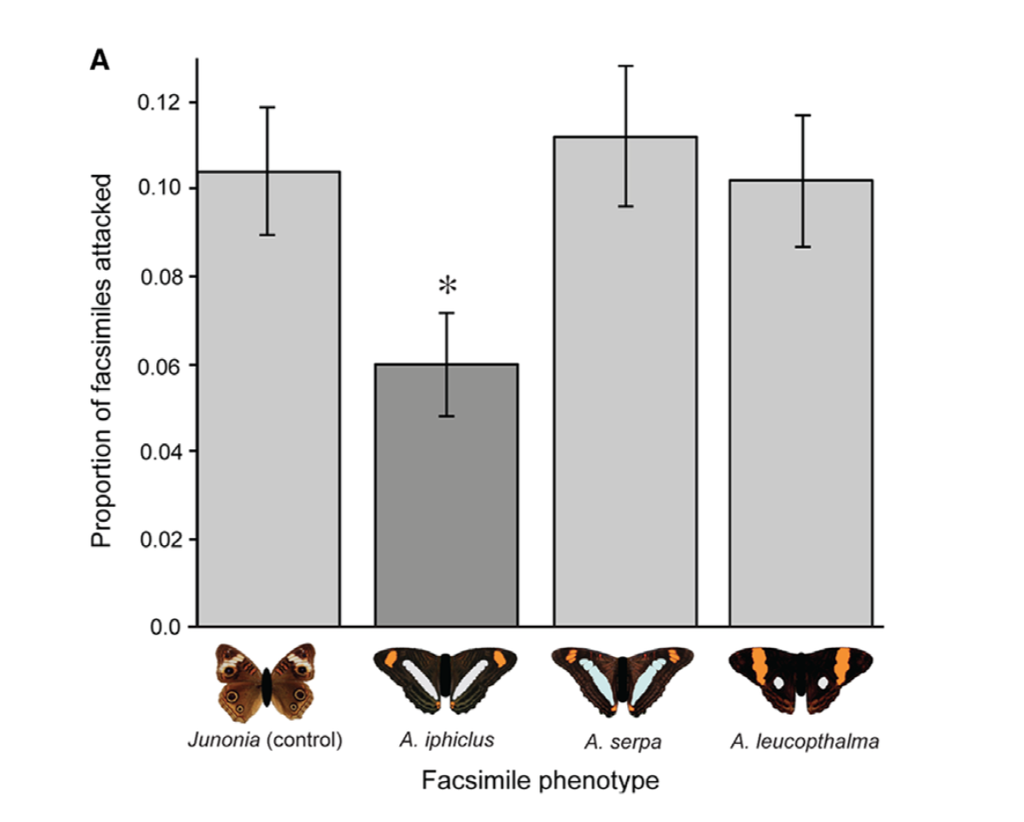

and here is my replication:

first, lets load in the required packages!

```r
library(ggplot2)
library(ggimage)
library(dplyr)
```

the first step of this replication is creating a new dataset that includes information about the images we want to associate with each variable

```r
name <- c("evarete", "iphiclus", "serpa", "leucopthalma")
total.attacks <- c(52, 30, 56, 51)
rates <- cbind((total.attacks/500))
image <- c("https://raw.githubusercontent.com/butterfliesrcool/BI588_Replication_Assignment/main/evarete.jpeg", "https://raw.githubusercontent.com/butterfliesrcool/BI588_Replication_Assignment/main/iphiclus.jpeg", "https://raw.githubusercontent.com/butterfliesrcool/BI588_Replication_Assignment/main/serpa.png", "https://raw.githubusercontent.com/butterfliesrcool/BI588_Replication_Assignment/main/leucopthalma.jpeg")

rate.data <- data.frame(name, total.attacks, rates, image)
rate.data
```

```
##           name total.attacks rates
## 1      evarete            52 0.104
## 2     iphiclus            30 0.060
## 3        serpa            56 0.112
## 4 leucopthalma            51 0.102
##                                                                                                    image
## 1      https://raw.githubusercontent.com/butterfliesrcool/BI588_Replication_Assignment/main/evarete.jpeg
## 2     https://raw.githubusercontent.com/butterfliesrcool/BI588_Replication_Assignment/main/iphiclus.jpeg
## 3         https://raw.githubusercontent.com/butterfliesrcool/BI588_Replication_Assignment/main/serpa.png
## 4 https://raw.githubusercontent.com/butterfliesrcool/BI588_Replication_Assignment/main/leucopthalma.jpeg
```

The next preliminary step is creating a subsetted object of just iphiclus. We will use this in the ggplot code to insert an * to represent that our analyses indicate that attack rates on iphiclus are significantly lower.

```r
iph <- subset(rate.data, name  == "iphiclus", drop = FALSE)
```

and finally, we can create the figure using ggplot!

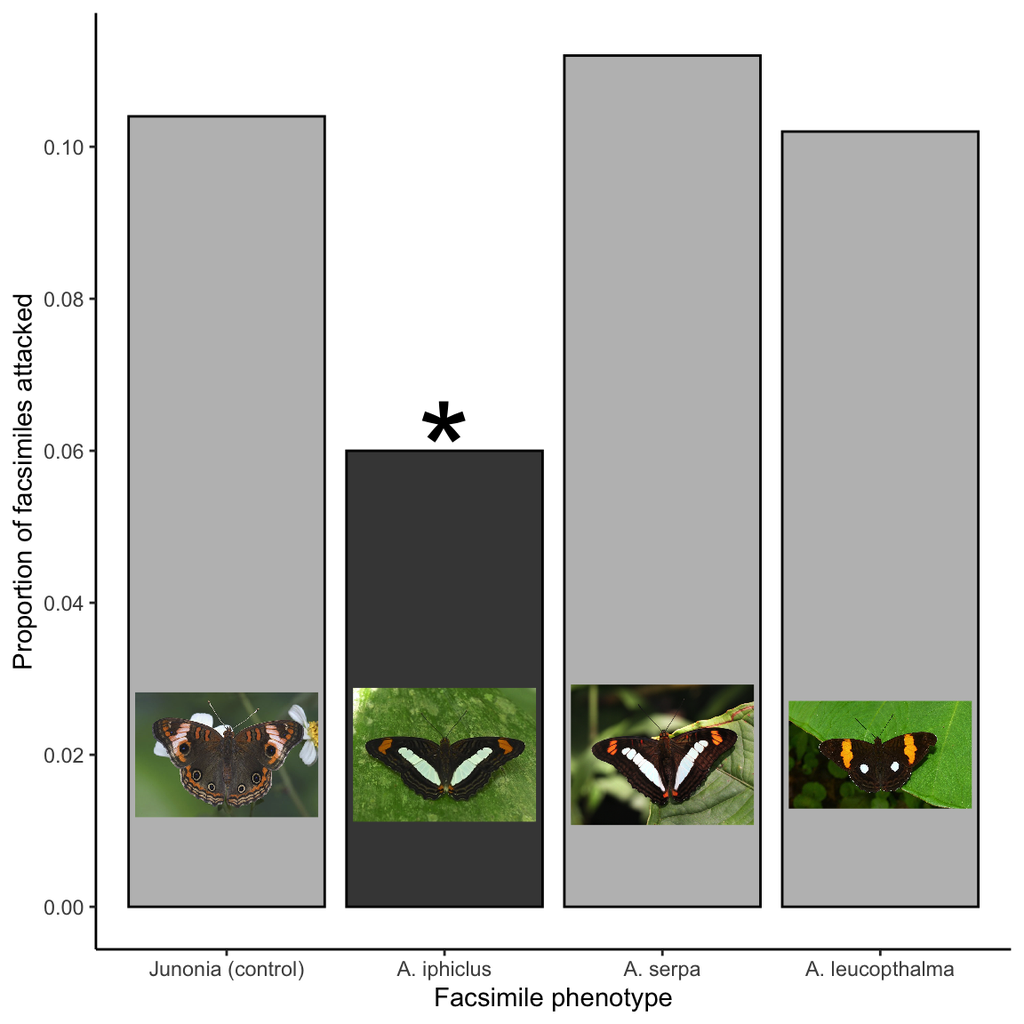

```r
b <- ggplot(rate.data, aes(x=name, y=rates))

b <- b + geom_col()
#geom_col() is necessary for inserting the images with geom_image

b <- b + geom_bar(stat="identity", color="black",fill=c("grey", "grey27", "grey", "grey"))
#geom_bar creates the bar plot, the commands "color=" and "fill=" allow you to change the color of the bar outlines and fill, respectively

b <- b + geom_image(aes(image=image, y = 0.02), size=.2)
##y= specifies the location of the image along the y axis

b <- b + geom_text(data = iph, label = "*", size = 20)
#use geom_text to insert the * above the iphiclus column

b <- b + theme_minimal()
b <- b + theme_classic()
#this code removes the automated background in the ggplot, which allows us to match the theme of the grpah presented in the paper

b <- b + xlab("Facsimile phenotype")
b <- b + ylab("Proportion of facsimiles attacked")
#use xlab and ylab to label the axis

b <- b + scale_x_discrete(limits =  c("evarete", "iphiclus", "serpa", "leucopthalma"), labels = c("evarete" = "Junonia (control)","iphiclus" = "A. iphiclus", "serpa" = "A. serpa",  "leucopthalma" = "A. leucopthalma") )
#R will usually automatically sort variables alphabetically, so the "limits" command here allows you to override that and manually specify the order of variables in the ggplot.

b <- b + scale_y_continuous(breaks = seq(0.0, 0.12, 0.02))
#seq() command specifies seq(to, from, by=)
#scale_x_discrete and scale_y_continuous commands allow you to rename the variables on the x and y axis either as discrete (usually categorical) variables or a continuous series of numbers. t


b #load the final product!
```

# Survival Analysis

load survival and survminer packages

```r
library(survival)
library(survminer)
```

use the curl command to reload the binomial data (if you didn’t do so above)

```r
p <- curl("https://raw.githubusercontent.com/butterfliesrcool/BI588_Replication_Assignment/main/Adelpha2016_binomial.csv")
binomial.data  <- read.csv(p, header = TRUE, sep = ",", stringsAsFactors = FALSE)
```

```r
model <- survfit(Surv(day, day+1, attacks) ~ species, data=binomial.data)
model
```

```
## Call: survfit(formula = Surv(day, day + 1, attacks) ~ species, data = binomial.data)
##
##                      records   n events median 0.95LCL 0.95UCL
## species=evarete         2000 500     52     NA      NA      NA
## species=iphiclus        2000 500     30     NA      NA      NA
## species=leucopthalma    2000 500     51     NA      NA      NA
## species=serpa           2000 500     56     NA      NA      NA
```

```r
summary(model)
```

```
## Call: survfit(formula = Surv(day, day + 1, attacks) ~ species, data = binomial.data)
##
##                 species=evarete
##  time n.risk n.event survival std.err lower 95% CI upper 95% CI
##     2    500      18    0.964 0.00833        0.948        0.980
##     3    500      12    0.941 0.01047        0.921        0.962
##     4    500      12    0.918 0.01208        0.895        0.942
##     5    500      10    0.900 0.01316        0.874        0.926
##
##                 species=iphiclus
##  time n.risk n.event survival std.err lower 95% CI upper 95% CI
##     2    500      17    0.966 0.00810        0.950        0.982
##     3    500       6    0.954 0.00929        0.936        0.973
##     4    500       5    0.945 0.01013        0.925        0.965
##     5    500       2    0.941 0.01043        0.921        0.962
##
##                 species=leucopthalma
##  time n.risk n.event survival std.err lower 95% CI upper 95% CI
##     2    500      20    0.960 0.00876        0.943        0.977
##     3    500      10    0.941 0.01048        0.920        0.962
##     4    500       9    0.924 0.01172        0.901        0.947
##     5    500      12    0.902 0.01307        0.876        0.928
##
##                 species=serpa
##  time n.risk n.event survival std.err lower 95% CI upper 95% CI
##     2    500      25    0.950 0.00975        0.931        0.969
##     3    500      15    0.921 0.01191        0.898        0.945
##     4    500      11    0.901 0.01313        0.876        0.927
##     5    500       5    0.892 0.01360        0.866        0.919
```

```r
coxph(Surv(day, day+1, attacks) ~ species, data=binomial.data)
```

```
## Call:
## coxph(formula = Surv(day, day + 1, attacks) ~ species, data = binomial.data)
##
##                         coef exp(coef) se(coef)      z      p
## speciesiphiclus     -0.55437   0.57444  0.22927 -2.418 0.0156
## speciesleucopthalma -0.01929   0.98090  0.19708 -0.098 0.9220
## speciesserpa         0.07685   1.07988  0.19258  0.399 0.6898
##
## Likelihood ratio test=9.73  on 3 df, p=0.02105
## n= 8000, number of events= 189
```

Subset specific species pairwise comparisons from “binomial.data”

```r
ei <- subset(binomial.data, species %in% c("evarete", "iphiclus"), drop = FALSE)
si <- subset(binomial.data, species %in% c("serpa", "iphiclus"), drop = FALSE)
li <- subset(binomial.data, species %in% c("leucopthalma", "iphiclus"), drop = FALSE)
le <- subset(binomial.data, species %in% c("leucopthalma", "evarete"), drop = FALSE)
ls <- subset(binomial.data, species %in% c("leucopthalma", "serpa"), drop = FALSE)
es <- subset(binomial.data, species %in% c("evarete", "serpa"), drop = FALSE)
```

evarete-iphiclus comparison (significant)

```r
coxph(Surv(day, day+1, attacks) ~ species, data=ei)
```

```
## Call:
## coxph(formula = Surv(day, day + 1, attacks) ~ species, data = ei)
##
##                    coef exp(coef) se(coef)      z      p
## speciesiphiclus -0.5542    0.5745   0.2293 -2.417 0.0156
##
## Likelihood ratio test=6.07  on 1 df, p=0.01377
## n= 4000, number of events= 82
```

serpa-iphiclus comparison (significant)

```r
coxph(Surv(day, day+1, attacks) ~ species, data=si)
```

```
## Call:
## coxph(formula = Surv(day, day + 1, attacks) ~ species, data = si)
##
##                coef exp(coef) se(coef)     z       p
## speciesserpa 0.6315    1.8804   0.2263 2.791 0.00525
##
## Likelihood ratio test=8.18  on 1 df, p=0.004245
## n= 4000, number of events= 86
```

leucopthalma-iphiclus comparison (significant)

```r
coxph(Surv(day, day+1, attacks) ~ species, data=li)
```

```
## Call:
## coxph(formula = Surv(day, day + 1, attacks) ~ species, data = li)
##
##                       coef exp(coef) se(coef)     z      p
## speciesleucopthalma 0.5350    1.7075   0.2301 2.325 0.0201
##
## Likelihood ratio test=5.6  on 1 df, p=0.01796
## n= 4000, number of events= 81
```

leucopthalma-evarete comparison (not significant)

```r
coxph(Surv(day, day+1, attacks) ~ species, data=le)
```

```
## Call:
## coxph(formula = Surv(day, day + 1, attacks) ~ species, data = le)
##
##                         coef exp(coef) se(coef)      z     p
## speciesleucopthalma -0.01927   0.98091  0.19708 -0.098 0.922
##
## Likelihood ratio test=0.01  on 1 df, p=0.9221
## n= 4000, number of events= 103
```

leucopthalma-serpa comparison (not significant)

```r
coxph(Surv(day, day+1, attacks) ~ species, data=ls)
```

```
## Call:
## coxph(formula = Surv(day, day + 1, attacks) ~ species, data = ls)
##
##                 coef exp(coef) se(coef)     z    p
## speciesserpa 0.09609   1.10086  0.19356 0.496 0.62
##
## Likelihood ratio test=0.25  on 1 df, p=0.6194
## n= 4000, number of events= 107
```

evarete-serpa comparison (not significant)

```r
coxph(Surv(day, day+1, attacks) ~ species, data=es)
```

```
## Call:
## coxph(formula = Surv(day, day + 1, attacks) ~ species, data = es)
##
##                 coef exp(coef) se(coef)     z    p
## speciesserpa 0.07678   1.07981  0.19258 0.399 0.69
##
## Likelihood ratio test=0.16  on 1 df, p=0.69
## n= 4000, number of events= 108
```

While Finkbeiner did not report using the pairwise_survdiff() function in her publication, this is another possibly easier way to generate pairwise comparisons in the survival differences between species.

```r
survdiff(Surv(day, attacks) ~ species, data=binomial.data)
```

```
## Call:
## survdiff(formula = Surv(day, attacks) ~ species, data = binomial.data)
##
##                         N Observed Expected (O-E)^2/E (O-E)^2/V
## species=evarete      2000       52     47.2     0.478     0.643
## species=iphiclus     2000       30     47.2     6.298     8.479
## species=leucopthalma 2000       51     47.2     0.298     0.401
## species=serpa        2000       56     47.2     1.620     2.182
##
##  Chisq= 8.8  on 3 degrees of freedom, p= 0.03
```

```r
pairwise_survdiff(Surv(day, attacks) ~ species, p.adjust.method = "BH",
     data = binomial.data)
```

```
##
##  Pairwise comparisons using Log-Rank test
##
## data:  binomial.data and species
##
##              evarete iphiclus leucopthalma
## iphiclus     0.038   -        -
## leucopthalma 0.921   0.038    -
## serpa        0.839   0.029    0.839
##
## P value adjustment method: BH
```

# Figure 1(B)

Here is a screenshot of the original figure:

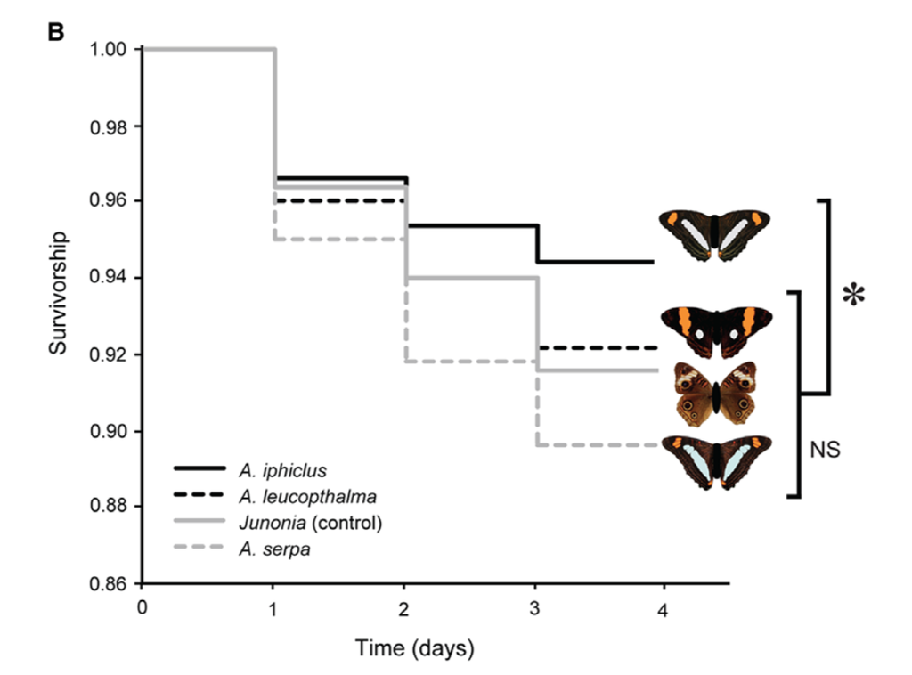

image

Load the libraries!

```r
library(ggplot2)
library(tayloRswift)
```

We can plot the survfit model generated above in baseR using the function plot()

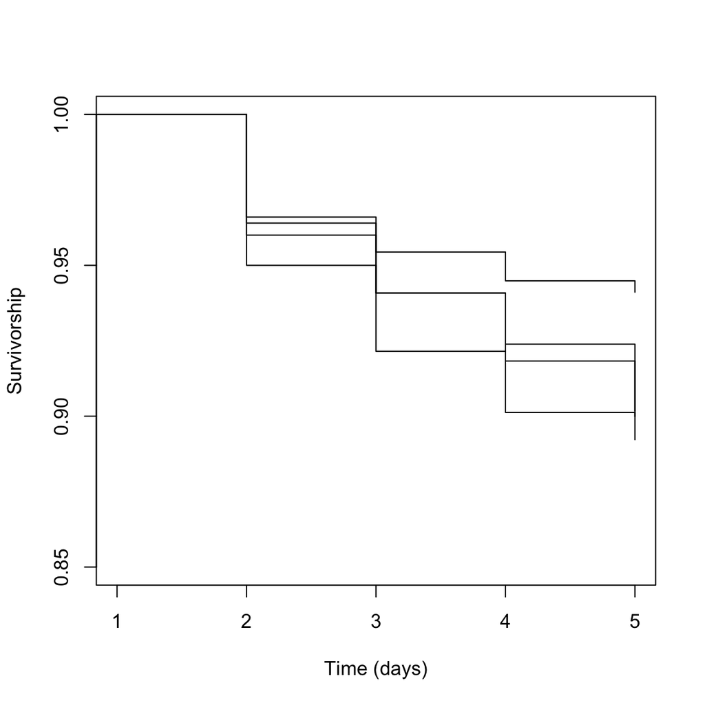

```r
plot(model, xlab="Time (days)",
           ylab="Survivorship",
           ylim = c(0.85, 1.0),
           xlim = c(1, 5))
```

If we want to get fancy, we can also plot this model using ggsurvplot()

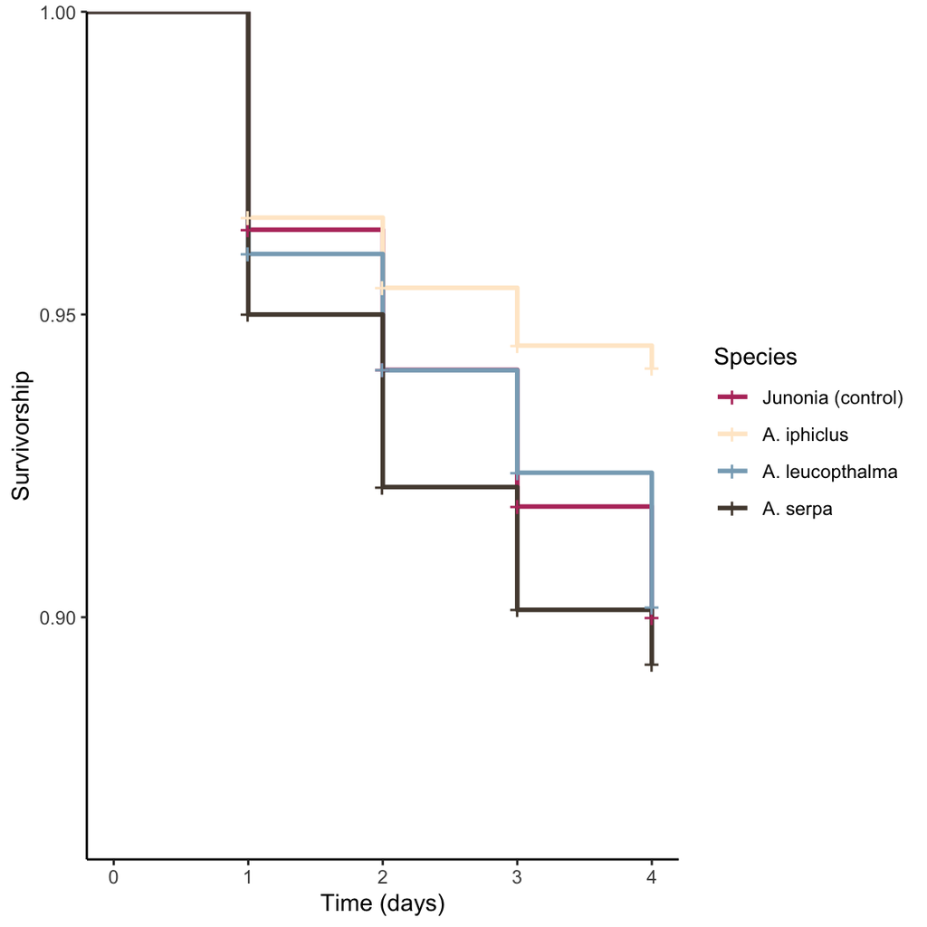

```r
p <- ggsurvplot(fit = model,
           xaxt = "n",
           xlab="Time (days)",
           ylab="Survivorship",
           ylim = c(0.86, 1.0),
           xlim = c(1, 5),
           data = binomial.data,
           axes = FALSE,
           linetype = 1,
           legend.labs = c("Junonia (control)", "A. iphiclus", "A. leucopthalma", "A. serpa"),
           legend.title = "Species")

##use Red (Taylor's Version) color palette
p$plot <- p$plot + scale_color_taylor(palette = "lover")
#set your favorite Taylor album as your color palette! Try "folklore" or "evermore" or "taylorRed"

p$plot <- p$plot + theme_minimal()
p$plot <- p$plot + theme_classic()

##rename the x axis values
p$plot <- p$plot + scale_x_continuous(breaks = c(1,2,3,4,5), labels = c(0,1,2,3,4))
p$plot
```

# Challenges

1. One of my biggest challenges with this project was trying to figure out how to format the data for each analysis. Susan Finkbeiner uploaded the dataset to DataDryad, but it was not in a format that count be read into R, it was also uploaded as count data when all of the survival analyses performed in this publication required binomial data.
2. I also struggled with graphing the glm directly in ggplot, the figure in the paper reports attack rates, but the glm was performed on attack totals. This made it difficult to include error bars in the figure

# Resources

-http://www.sthda.com/english/wiki/ggplot2-themes-and-background-colors-the-3-elements

-https://www.geeksforgeeks.org/change-color-of-bars-in-barchart-using-ggplot2-in-r/

-http://sape.inf.usi.ch/quick-reference/ggplot2/colour

-https://www.delftstack.com/howto/r/scale_y_continuous-in-r/

-https://stackoverflow.com/questions/25061822/ggplot-geom-text-font-size-control/25062509

-https://stackoverflow.com/questions/21234833/selecting-a-subset-where-a-categorical-variable-column-can-have-2-values

-https://cran.r-project.org/web/packages/ggimage/ggimage.pdf

-https://www.statology.org/r-add-a-column-to-dataframe/

-https://stackoverflow.com/questions/56399019/how-to-manually-add-an-error-bar-95-ci-to-a-barplot

-https://community.rstudio.com/t/how-to-get-r-to-maintain-the-order-of-variables-on-the-x-axis/31203/11

-https://stackoverflow.com/questions/20620277/get-95-confidence-interval-with-glm-in-r

-https://stackoverflow.com/questions/50546109/ggimage-custom-image-from-computer-rather-than-from-web

-https://stackoverflow.com/questions/60764518/inserting-an-image-to-a-bar-chart-in-ggplot

-https://rkabacoff.github.io/datavis/datavis.pdf